# Homework 6

Ani Bilazarian

11/20/2019

# Problem 1

*Reading in Birthweight Data*

```r
birthweight =
  read_csv("./data/birthweight.csv")
```

*Cleaning Birthweight Data*

```r
birthweight_clean =
  birthweight %>%
  janitor::clean_names() %>%
  drop_na() %>%
  mutate(mrace = as.factor(mrace),
         babysex = as.character(babysex),
         frace = as.factor(frace),
         malform = as.character(malform)) %>%
    mutate(mrace = recode(mrace,
                   '1' = "white",
                   '2' = "black",
                   '3' = "asian",
                   '4' = "puerto rican",
                   '8' = "other")) %>%
    mutate(frace = recode(frace,
                   '1' = "white",
                   '2' = "black",
                   '3' = "asian",
                   '4' = "puerto rican",
                   '8' = "other",
                   '9' = "unknown"))
```

*Proposing a regression model based on hypothesized structure*

```r
fit = lm(bwt ~ mrace + fincome + gaweeks, data = birthweight_clean)

fit %>%
  broom::tidy() %>%
  select(term, estimate, p.value) %>%
  mutate(term = str_replace(term, "mrace", "Mother's Race: ")) %>%
  knitr::kable(digits = 3)
```

| term | estimate | p.value |
| --- | --- | --- |
| (Intercept) | 843.890 | 0.000 |
| Mother’s Race: black | -232.759 | 0.000 |
| Mother’s Race: asian | -114.769 | 0.100 |
| Mother’s Race: puerto rican | -147.107 | 0.000 |
| fincome | 0.554 | 0.054 |
| gaweeks | 59.802 | 0.000 |

I chose this model as research indicates that mother’s race, income, and gestational age are determinants of low birthweight. This [study](https://www.ncbi.nlm.nih.gov/pmc/articles/PMC5014333/) found that African-American and Latino mothers who smoked and lived in poorer communities were three times more likely to have an infant with lower birth weight compared to non-smoking and wealthier women.

*Adding Residuals and Fitted Values*

```r
birthweight_clean =
  modelr::add_residuals(birthweight_clean, fit)

birthweight_clean =
modelr::add_predictions(birthweight_clean, fit)
```

*Plotting Residuals versus Fitted values*

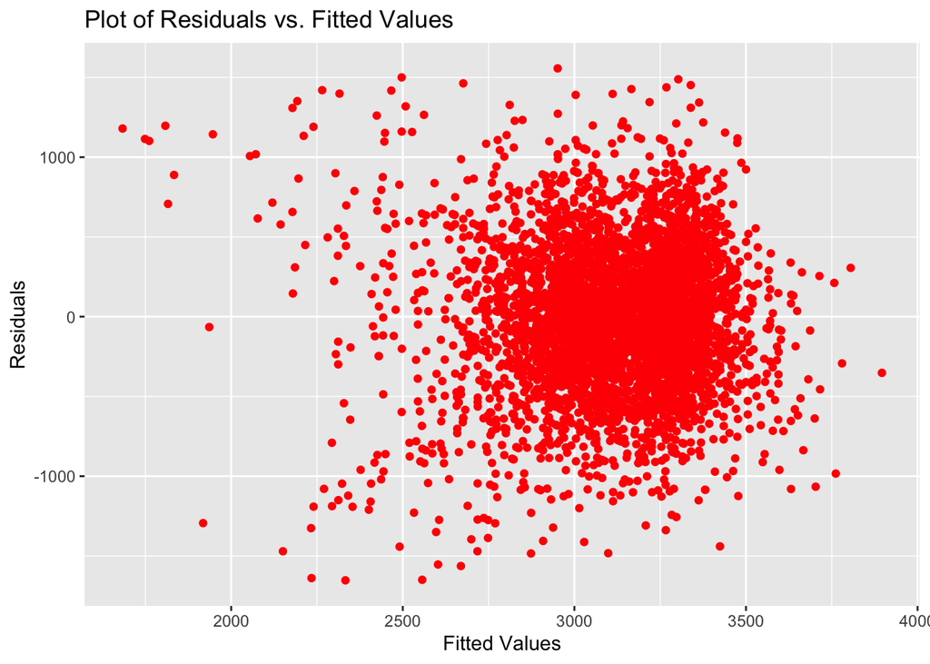

```r
birthweight_clean %>%
  ggplot(aes(x = pred, y = resid)) + geom_point(color = "red") + labs(x = "Fitted Values", y = "Residuals", title = "Plot of Residuals vs. Fitted Values")
```

*Comparing my model*

One using length at birth and gestational age as predictors (main effects only)

```r
main_effects = lm(bwt ~ blength + gaweeks, data = birthweight_clean)

main_effects %>%
  broom::tidy() %>%
  select(term, estimate, p.value) %>%
  mutate(term = str_replace(term, "mrace", "Mother's Race: ")) %>%
  knitr::kable(digits = 3)
```

| term | estimate | p.value |
| --- | --- | --- |
| (Intercept) | -4347.667 | 0 |
| blength | 128.556 | 0 |
| gaweeks | 27.047 | 0 |

One using head circumference, length, sex, and all interactions (including the three-way interaction) between these

```r
interaction = lm(bwt ~ blength + babysex + bhead + blength * babysex + blength * bhead + bhead * babysex + blength * bhead * babysex, data = birthweight_clean)

interaction %>%
  broom::tidy() %>%
  select(term, estimate, p.value) %>%
  mutate(term = str_replace(term, "mrace", "Mother's Race: ")) %>%
  knitr::kable(digits = 3)
```

| term | estimate | p.value |
| --- | --- | --- |
| (Intercept) | -7176.817 | 0.000 |
| blength | 102.127 | 0.000 |
| babysex2 | 6374.868 | 0.000 |
| bhead | 181.796 | 0.000 |
| blength:babysex2 | -123.773 | 0.000 |
| blength:bhead | -0.554 | 0.478 |
| babysex2:bhead | -198.393 | 0.000 |
| blength:babysex2:bhead | 3.878 | 0.000 |

*Plotting each model*

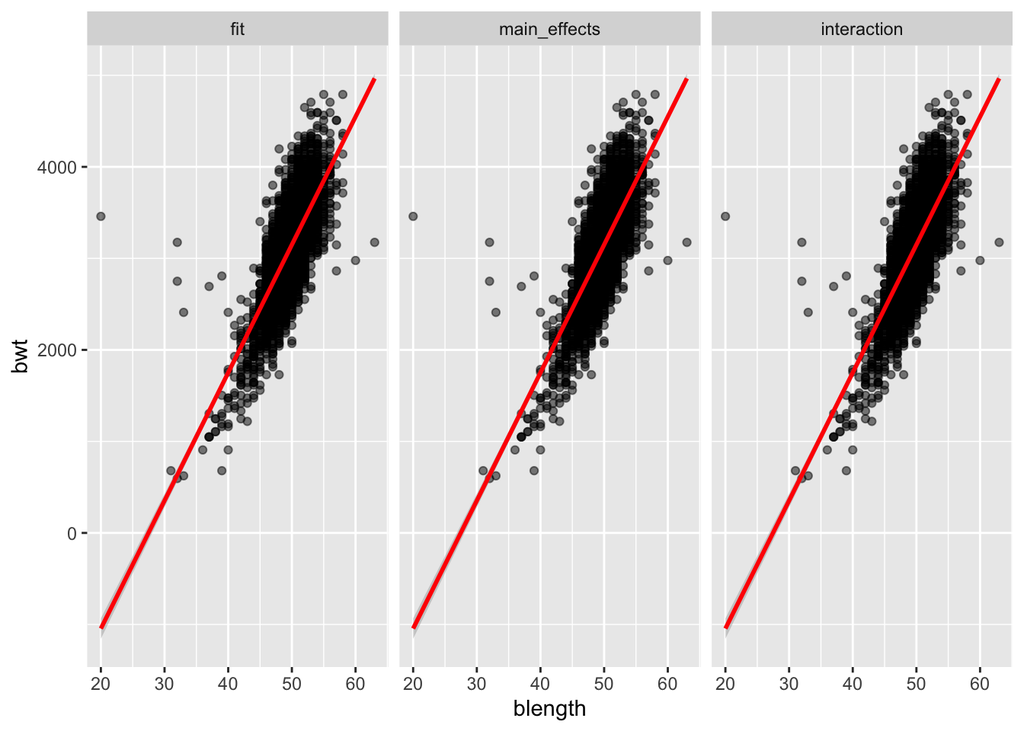

```r
  birthweight_clean %>%
  gather_predictions(fit, main_effects, interaction) %>%
  mutate(model = fct_inorder(model)) %>%
  ggplot(aes(x = blength, y = bwt)) +
  geom_point(alpha = .5) +
  geom_smooth(method = "lm", color = "red") +
  facet_grid(~model)
```

*Fit models to training data and obtain RMSEs*

```r
cv_df =
crossv_mc(birthweight, 100)

cv_df =
cv_df %>%
mutate(
main_effects = map(train, ~lm(bwt ~ blength + gaweeks, data = .x)),

interaction = map(train, ~lm(bwt ~ blength + babysex + bhead + blength * babysex + blength * bhead + bhead * babysex + blength * bhead * babysex, data = .x)),

fit = map(train, ~lm(bwt ~ mrace + fincome + gaweeks, data = .x))
) %>%

  mutate(
rmse_model_main_effects = map2_dbl(main_effects, test, ~rmse(model = .x, data = .y)),
rmse_model_interaction = map2_dbl(interaction, test, ~rmse(model = .x, data = .y)),
rmse_model_fit = map2_dbl(fit, test, ~rmse(model = .x, data = .y))
)
```

*Plot prediction error distribution for each model*

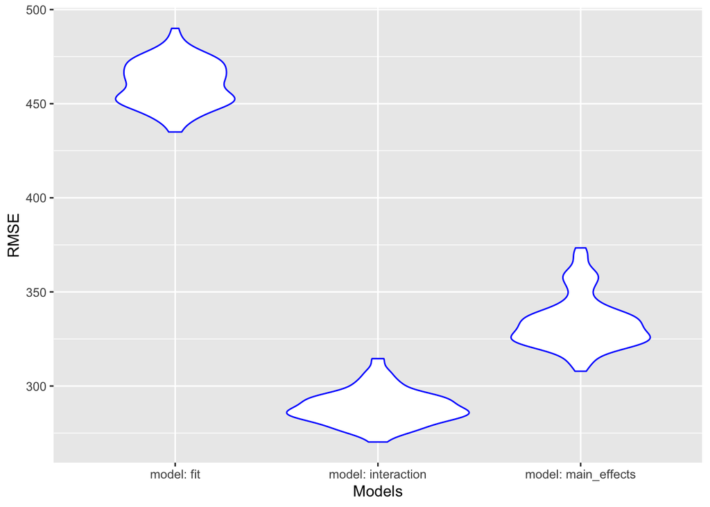

```r
cv_df %>%
  select(starts_with("rmse")) %>%
pivot_longer(
    everything(),
    names_to = "model",
    values_to = "rmse",
    names_prefix = "rmse_") %>%
  mutate(model = fct_inorder(model)) %>%
    mutate(model = str_replace(model, "model_", "model: ")) %>%

  ggplot(aes(x = model, y = rmse)) + geom_violin(color = "blue") + labs(x = "Models", y = "RMSE")
```

We can see based on the variance in prediction error that the model with interaction terms has the greatest predictive accuracy.

# Problem 2

*Importing weather data*

```r
weather_df =
  rnoaa::meteo_pull_monitors(
    c("USW00094728"),
    var = c("PRCP", "TMIN", "TMAX"),
    date_min = "2017-01-01",
    date_max = "2017-12-31") %>%
  mutate(
    name = recode(id, USW00094728 = "CentralPark_NY"),
    tmin = tmin / 10,
    tmax = tmax / 10) %>%
  select(name, id, everything())
```

_Produce estimate of log(Bo^*B1^) using 5000 bootstrap estimates_

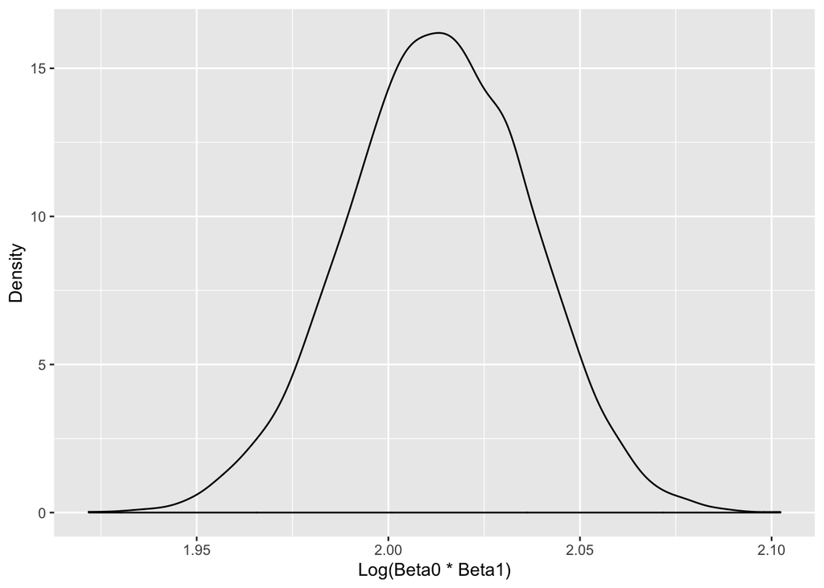

```r
set.seed(1)

weather_df %>%
  modelr::bootstrap(n = 5000) %>%
  mutate(models = map(strap, ~ lm(tmax ~ tmin, data = .x)),
    results = map(models, broom::tidy)) %>%
  select(results) %>%
  unnest(results) %>%
select(term, estimate) %>%
  pivot_wider(
names_from = term, values_from = estimate) %>%
  unnest() %>%
  janitor::clean_names() %>%
mutate(log_intercept = log(intercept*tmin)) %>%
    ggplot(aes(x = log_intercept)) + geom_density() + labs(x = "Log(Beta0 * Beta1)", y = "Density")
```

This distribution does not have heavy tails indicating that there are few outliers and data is approximately normally distributed.

*Produce estimate of R Squared using 5000 bootstrap estimates*

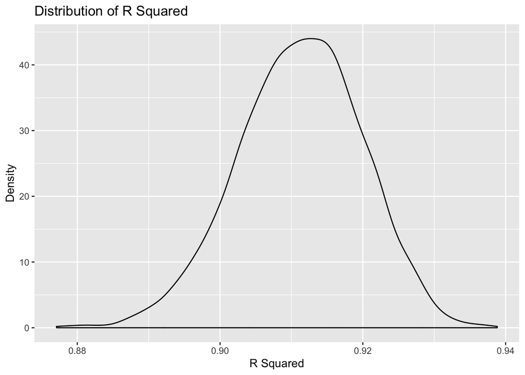

```r
  weather_df %>%
  modelr::bootstrap(n = 5000) %>%
  mutate(models = map(strap, ~ lm(tmax ~ tmin, data = .x)),
    results = map(models, broom::glance)) %>%
  select(results) %>%
  unnest(results) %>%
  select(r.squared) %>%
  ggplot(aes(x = r.squared)) + geom_density() + labs(x = "R Squared", y = "Density", title = "Distribution of R Squared")
```

Similar to the log distribution, the R squared distribution does not have heavy tails indicating few outliers and data is approximately normally distributed.

*95% CI for R.Squared*

```r
  weather_df %>%
  modelr::bootstrap(n = 5000) %>%
  mutate(models = map(strap, ~ lm(tmax ~ tmin, data = .x)),
    results = map(models, broom::glance)) %>%
  select(results) %>%
  unnest(results) %>%
  select(r.squared) %>%
summarize(
lower_CI = quantile(r.squared, c(.025)),
upper_CI = quantile(r.squared, c(.975))) %>%
  knitr::kable()
```

| lower_CI | upper_CI |
| --- | --- |
| 0.8937522 | 0.9270975 |

The 95% CI for R Squared is 0.89 to 0.93.

_95% CI for log(beta0*beta1)_

```r
weather_df %>%
  modelr::bootstrap(n = 5000) %>%
  mutate(models = map(strap, ~ lm(tmax ~ tmin, data = .x)),
    results = map(models, broom::tidy)) %>%
  select(results) %>%
  unnest(results) %>%
select(term, estimate) %>%
  pivot_wider(
names_from = term, values_from = estimate) %>%
  unnest() %>%
  janitor::clean_names() %>%
mutate(log_intercept = log(intercept*tmin)) %>%
summarize(
lower_CI = quantile(log_intercept, c(.025)),
upper_CI = quantile(log_intercept, c(.975))) %>%
  knitr::kable()
```

| lower_CI | upper_CI |
| --- | --- |
| 1.967353 | 2.058287 |

The 95% CI for the log of beta null hat to beta one hat is 1.97 to 2.06.